# CART Examples

# Binary Outcome: Pima Indians Diabetes

Next, we classify diabetes status using the Pima Indians Diabetes dataset.

```r
data(PimaIndiansDiabetes2, package = "mlbench")
bin_df <- na.omit(PimaIndiansDiabetes2)
head(bin_df)
```

|  | pregnant | glucose | pressure | triceps | insulin | mass | pedigree | age | diabetes |
| --- | --- | --- | --- | --- | --- | --- | --- | --- | --- |
| 4 | 1 | 89 | 66 | 23 | 94 | 28.1 | 0.167 | 21 | neg |
| 5 | 0 | 137 | 40 | 35 | 168 | 43.1 | 2.288 | 33 | pos |
| 7 | 3 | 78 | 50 | 32 | 88 | 31.0 | 0.248 | 26 | pos |
| 9 | 2 | 197 | 70 | 45 | 543 | 30.5 | 0.158 | 53 | pos |
| 14 | 1 | 189 | 60 | 23 | 846 | 30.1 | 0.398 | 59 | pos |
| 15 | 5 | 166 | 72 | 19 | 175 | 25.8 | 0.587 | 51 | pos |

Distribution of outcome by candidate predictors

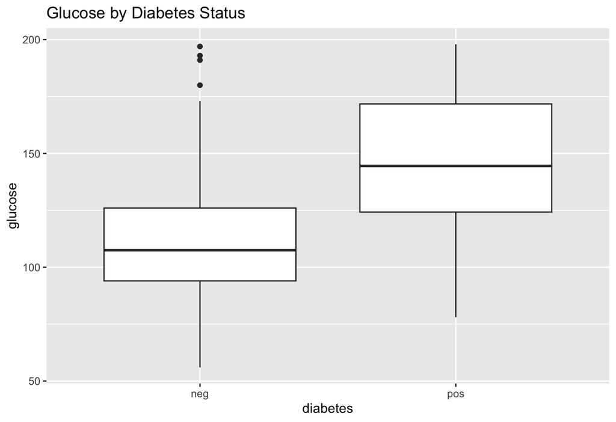

```r
ggplot(bin_df, aes(x = diabetes, y = glucose)) + geom_boxplot() +
  labs(title = "Glucose by Diabetes Status")
```

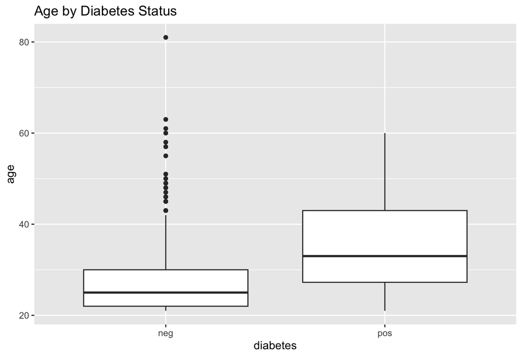

```r
ggplot(bin_df, aes(x = diabetes, y = age)) + geom_boxplot() +
  labs(title = "Age by Diabetes Status")
```

Fit CART with CV to select CP

```r
set.seed(735)
train_control <- trainControl(
  method = "cv",
  number = 10,
  classProbs = TRUE,
  summaryFunction = twoClassSummary)

cart_class <- train(diabetes ~ ., data = bin_df, method = "rpart",
                    trControl = train_control,
                    metric = "ROC",
                    tuneLength = 10)
cart_class
```

```
## CART
##
## 392 samples
##   8 predictor
##   2 classes: 'neg', 'pos'
##
## No pre-processing
## Resampling: Cross-Validated (10 fold)
## Summary of sample sizes: 353, 353, 353, 353, 352, 353, ...
## Resampling results across tuning parameters:
##
##   cp          ROC        Sens       Spec
##   0.00000000  0.8128041  0.8544160  0.6153846
##   0.03162393  0.7706443  0.8273504  0.6769231
##   0.06324786  0.7586621  0.8311966  0.6615385
##   0.09487179  0.7533092  0.7933048  0.6923077
##   0.12649573  0.7524217  0.7817664  0.7230769
##   0.15811966  0.7524217  0.7817664  0.7230769
##   0.18974359  0.7524217  0.7817664  0.7230769
##   0.22136752  0.7524217  0.7817664  0.7230769
##   0.25299145  0.7524217  0.7817664  0.7230769
##   0.28461538  0.6442308  0.8346154  0.4538462
##
## ROC was used to select the optimal model using the largest value.
## The final value used for the model was cp = 0.
```

**Code Explanation**

- `train()` is from the caret package and is a wrapper for fitting models with built-in resampling.
- `diabetes ~ .` means we’re predicting the diabetes variable using all other variables (.).
- `method = "rpart"` tells caret to fit a classification tree using the rpart package.
- `trainControl()`sets how the resampling is done:
- `method = "cv"` → perform cross-validation.
- `number = 10`→ 10 folds.
- `classProbs = TRUE` → compute class probabilities (not just predicted classes).
- `summaryFunction = twoClassSummary` → calculate metrics like ROC AUC, sensitivity, specificity.
- `metric = "ROC"` tells caret to optimize the model based on ROC AUC.
- `tuneLength = 10` → caret will try 10 different values of the complexity parameter (cp) for the tree, then pick the one with the best AUC.

So, this code finds the “best” CART tree for the Pima data, based on cross-validated ROC AUC.

## Final CART tree

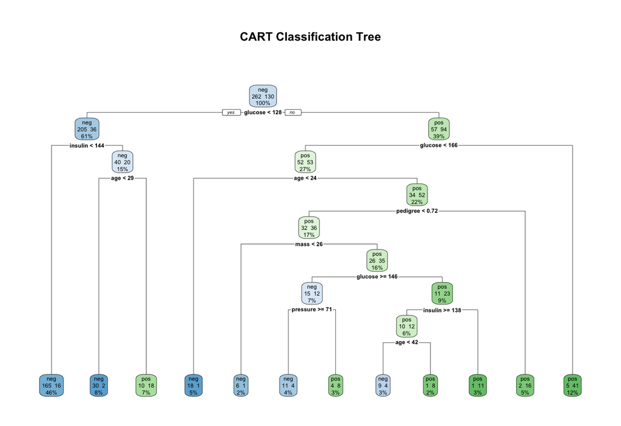

```r
best_tree_class <- cart_class$finalModel
rpart.plot(best_tree_class, main = "CART Classification Tree", extra = 101)
```

⸻

# Compare CART vs Naive Bayes for Pima Indians Diabetes

## Naive Bayes model

Here, we are going to fit the Naive Bayes model with the `naivebayes` package.

```r
set.seed(735)
nb_model <- train(diabetes ~ ., data = bin_df, method = "naive_bayes",
                  trControl = train_control,
                  metric = "ROC")
nb_model
```

```
## Naive Bayes
##
## 392 samples
##   8 predictor
##   2 classes: 'neg', 'pos'
##
## No pre-processing
## Resampling: Cross-Validated (10 fold)
## Summary of sample sizes: 353, 353, 353, 353, 352, 353, ...
## Resampling results across tuning parameters:
##
##   usekernel  ROC        Sens       Spec
##   FALSE      0.8345387  0.8279202  0.6384615
##    TRUE      0.8390423  0.8008547  0.6692308
##
## Tuning parameter 'laplace' was held constant at a value of 0
## Tuning
##  parameter 'adjust' was held constant at a value of 1
## ROC was used to select the optimal model using the largest value.
## The final values used for the model were laplace = 0, usekernel = TRUE
##  and adjust = 1.
```

**Code Explanation**

• Very similar to the CART example, but `method = "naive_bayes"` tells caret to use a Naive Bayes classifier (via the `naivebayes` package).

• Again, it uses the same cross-validation settings (train_control).

• `metric = "ROC"` means caret will pick the tuning parameter values that maximize the ROC AUC.

## Compare ROC AUC

```r
results <- resamples(list(CART = cart_class, NB = nb_model))
```

**Code Explanation**

• `resamples()` is a caret function that takes multiple fitted caret models (here cart_class and nb_model) and extracts the resampling results (cross-validation scores).

• `list(CART = cart_class, NB = nb_model)` names each model so they can be compared side by side.

```r
summary(results)
```

```
##
## Call:
## summary.resamples(object = results)
##
## Models: CART, NB
## Number of resamples: 10
##
## ROC
##           Min.   1st Qu.    Median      Mean  3rd Qu.      Max. NA's
## CART 0.7056213 0.7629438 0.8254438 0.8128041 0.843976 0.9059829    0
## NB   0.7366864 0.7998028 0.8313609 0.8390423 0.887574 0.9515670    0
##
## Sens
##           Min.   1st Qu.    Median      Mean   3rd Qu.      Max. NA's
## CART 0.7307692 0.7788462 0.8846154 0.8544160 0.9252137 0.9615385    0
## NB   0.6538462 0.7403846 0.8076923 0.8008547 0.8383191 0.9629630    0
##
## Spec
##           Min.   1st Qu.    Median      Mean   3rd Qu.      Max. NA's
## CART 0.3846154 0.5576923 0.6153846 0.6153846 0.7307692 0.8461538    0
## NB   0.3846154 0.5769231 0.6923077 0.6692308 0.7692308 0.8461538    0
```

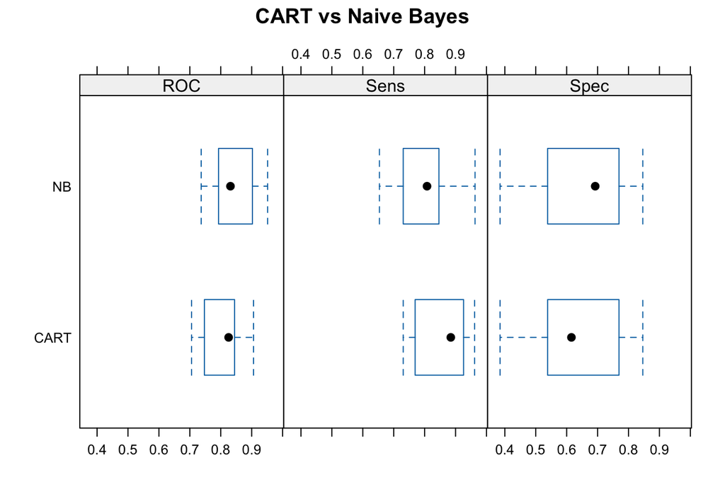

```r
bwplot(results, main = "CART vs Naive Bayes")
```

⸻

Key Takeaways

• CART flexibly partitions the predictor space for continuous or binary outcomes.

• Cross-validation is essential for tuning tree complexity (cp).

• CART trees are interpretable but may not always perform as well as other classifiers.

• Naive Bayes provides a useful baseline for classification problems and often complements CART in comparison.